# STAT574E Group 3 Final Project Appendix

Alex Salce, Raymond Owino, Matthew Wallace

2024-11-29

Packages we need.

We have a few datasets that we have pre-constructed based on available resources and challenges with acquiring data for the features that we are interested in modeling. Note that all `sf` objects are projected to `EPSG:3612` (https://epsg.io/32612).

- `wfigs_az_sf` is a `sf` object with 18089 observations of wildfire incidence in the state of Arizona. This data was originally acquired via [Wildland Fire Incident Locations](https://data-nifc.opendata.arcgis.com/datasets/nifc::wildland-fire-incident-locations/about) from the National Interagency Fire Center. It contains spatial point data indicating the origin of each wildfire recorded in the [IRWIN](https://www.wildfire.gov/application/irwin-integrated-reporting-wildfire-information) database, and includes many useful features. Most notably, the data includes the `IncidentSize`, which is the size in acres of the resulting wildfire. `IncidentSize` is the primary response variable of interest for our study. The data included in this dataframe includes hand-selected features that were deemed to be potentially useful during the exploration phase of the project, as well as other data manually recovered for natural and environmental factors, distances to roads in Arizona, as well as census data for population density, discussed elsewhere in the report.

-`az_rd_primary` and `az_rd_secondary` are `sf` data of all roads in Arizona with FCC road classification codes of `S1100` or `S1200`. These two classes are treated as “major” roads in our analyses. `az_rd_4WD` is all roads with `S1500` classification, and are representative of remote roadways in Arizona. All other road types are removed/disregarded as they are deemed not useful for our analysis. [See this document for all classification codes](https://docs.fcc.gov/public/attachments/DA-12-187A3.pdf).

```r
arizona_sf <- states() %>% filter_state("arizona")
arizona_sf <- st_transform(arizona_sf, crs = "EPSG:32612")

az_counties_sf <- counties(state = "AZ", cb = TRUE)
az_counties_sf <- st_transform(az_counties_sf, crs = "EPSG:32612")
```

First, we are going to load the `sf` object for the state of Arizona and project to `EPSG:32612`.

### Create Wildfire Dataframes

```r
az_fires_rx <- wfigs_az_sf %>% filter(IncidentTypeCategory=="RX")
az_fires_wf <- wfigs_az_sf %>% filter(IncidentTypeCategory=="WF")

az_fires_wf_hum <- az_fires_wf %>% filter(FireCause=="Human")
az_fires_wf_nat <- az_fires_wf %>% filter(FireCause=="Natural")
az_fires_wf_un <- az_fires_wf %>% filter(FireCause=="Undetermined" | FireCause=="Unknown")
```

For our analyses using `wfigs_az_sf`, we want to be sure to differentiate between fires that are prescribed burns (`IncidentTypeCategory=="RX"`) and wildfires (IncidentTypeCategory==“WF”). Our analyses will only use fires of type `WF`, since prescribed burns are fires deliberately started and controlled by a service entity.

We also want to differentiate fires by their causes. There are four unique categories of fire in the `FireCause` column, `HUMAN`, `NATURAL`, `UNDETERMINED`, and `UNKNOWN`. For our analyses, we will discard `UNDETERMINED` and `UNKNOWN` type fires, as we cannot reasonably assume anything about them. Additionally, they comprise only about 12% of all of the `wfigs_az_sf` data.

## Histograms

### Nearest Roads

This histogram uses input `sf` object to create `histdf`, which is used to generate a histogram of the number of closest roads, either primary/secondary roads or 4wd roads, to each wildfire incident origin. The $x$-axis indicates the distance in meters of that bin to wildfire points.

As a generalization, we will think of Primary & Secondary roads as essentially the same class of roads, and we know that many humans use these roads every day. No matter the stretch of road, there is a good chance of there being some human settlement of some kind alongside these roads within close proximity.

The “4WD” roads are technically a fairly “incomplete” dataset, but they do give a sense of areas humans can spend their time in remote areas. In general, though, if a wildfire incident is closer to a 4WD road we can think of it as being a “more remote” fire, i.e. there is a good chance it’s fairly removed from any prominent human settlement.

For reference, the minimum distances as well as the closest road type indicators were generated using the below code.

```r
wfigs_az_sf$distance_rd_primary <-
  st_distance(wfigs_az_sf, az_rd_primary) %>% apply(1, min)

wfigs_az_sf$distance_rd_secondary <-
  st_distance(wfigs_az_sf, az_rd_secondary) %>% apply(1, min)

wfigs_az_sf$distance_rd_4wd <-
  st_distance(wfigs_az_sf, az_rd_4wd) %>% apply(1, min)


wfigs_az_sf <- wfigs_az_sf %>%
  mutate(distance_rd_min_prisec = pmin(distance_rd_primary,
                                    distance_rd_secondary))

wfigs_az_sf <- wfigs_az_sf %>%
  mutate(distance_rd_min_all = pmin(distance_rd_primary,
                                    distance_rd_secondary,
                                    distance_rd_4wd))

wfigs_az_sf$distance_rd_min_isprisec <- as.integer(wfigs_az_sf$distance_rd_min_all ==
                                                     wfigs_az_sf$distance_rd_min_prisec)
```

#### All wildfire data

We will first look at the “Nearest Roads” histograms for all wildfire data (no filtering for the size of the fire.)

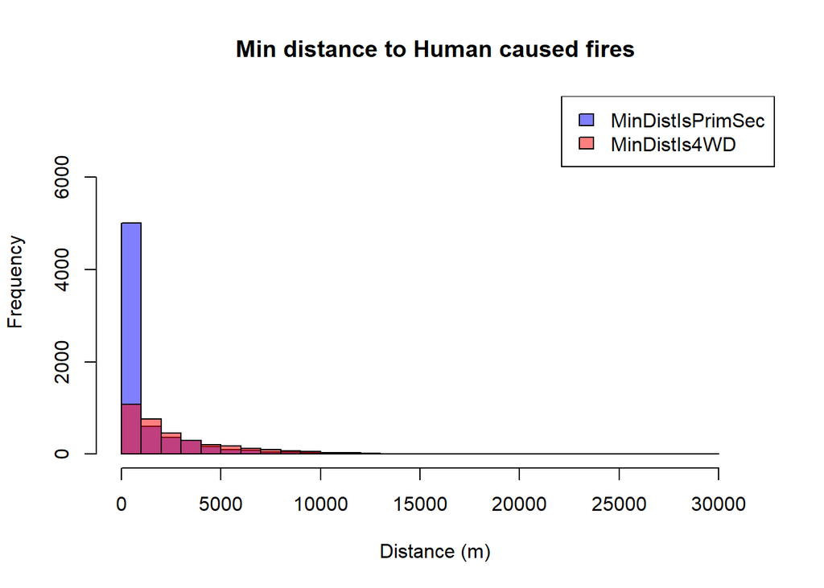

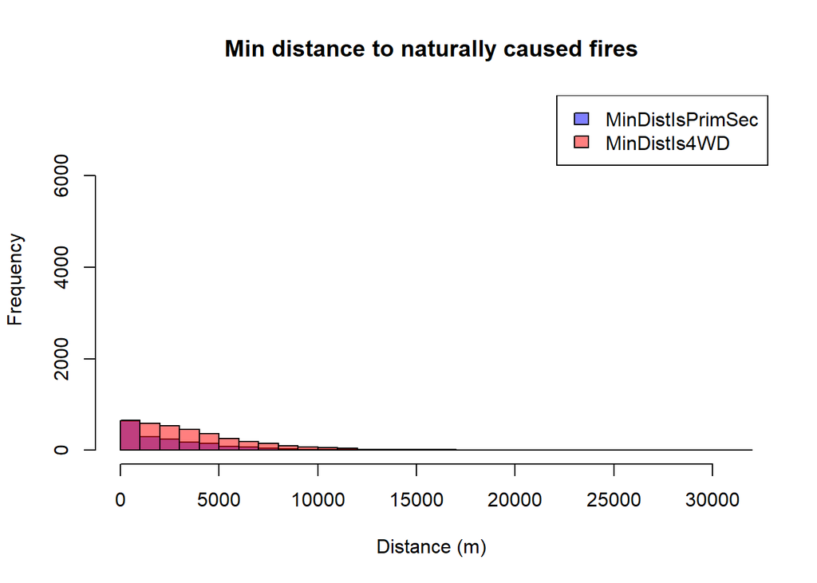

| WildFireType | Counts |
| --- | --- |
| Human Caused Fires | 10174 |
| Naturally Caused Fires | 5409 |
| Unknown Caused Fires | 2210 |

There is a very high concentration of wildfires cause by humans very close to primary and secondary roads, and natural fires generally seem to be more remote (in general closer to more 4WD roads.)

#### Thresholded for Wildfire Acreage

We define the threshold for a fire to be “large” as `IncidentSize` $\geq 1000$ acres. We threshold the data accordingly and replot our histograms.

```r
####################################
# RUN BELOW FOR FIRE SIZE THRESHOLD#
####################################


# fire size threshold
# FIRE_SIZE_CLASS = Code for fire size based on the number of acres within the
# final fire perimeter (A=greater than 0 but less than or equal to 0.25 acres,
# B=0.26-9.9 acres, C=10.0-99.9 acres, D=100-299 acres, E=300 to 999 acres,
# F=1000 to 4999 acres, and G=5000+ acres).

# class F and G fires
wf_size_threshold <- 1000

# max prescribed burn size
# wf_size_threshold <- max(az_fires_rx$IncidentSize)

wfigs_az_sf$size_threshold <- as.integer(wfigs_az_sf$IncidentSize >= wf_size_threshold)

wfigs_az_sf_thresh <- wfigs_az_sf %>% filter(size_threshold==1)
# wfigs_az_sf_thresh <- wfigs_az_sf %>% filter(IncidentSize >= wf_size_threshold)


az_fires_rx <- wfigs_az_sf_thresh %>% filter(IncidentTypeCategory=="RX")
az_fires_wf <- wfigs_az_sf_thresh %>% filter(IncidentTypeCategory=="WF")


#human caused wildfires

table(wfigs_az_sf_thresh$FireCause)
```

```
##
##        Human      Natural Undetermined      Unknown
##          102          255           62           20
```

```r
az_fires_wf_hum <- az_fires_wf %>% filter(FireCause=="Human")
az_fires_wf_nat <- az_fires_wf %>% filter(FireCause=="Natural")
az_fires_wf_un <- az_fires_wf %>% filter(FireCause=="Undetermined" | FireCause=="Unknown")
```

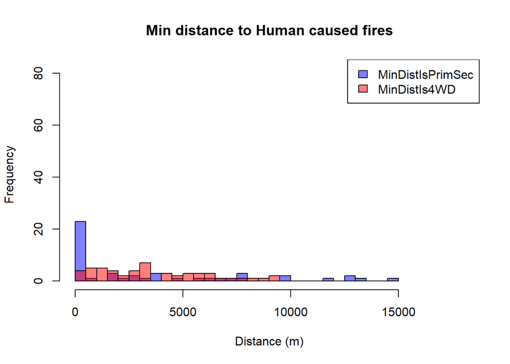

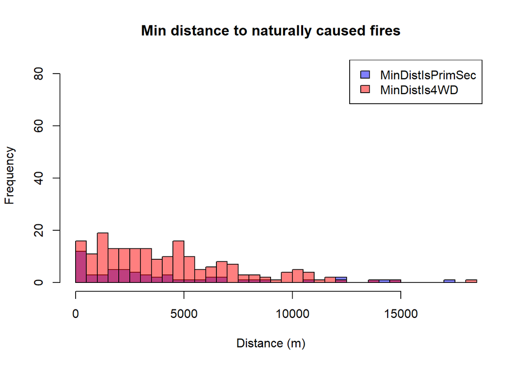

| WildFireType | Counts |
| --- | --- |
| Human Caused Fires | 101 |
| Naturally Caused Fires | 255 |
| Unknown Caused Fires | 33 |

## Models

### Spatial Linear Model - Raymond

A spatial linear model, capturing factors as well as spatial variation.

### Point Process Spatial Intensity Model - Matthew

Checking K, F, G functions to determine if wildfires are CSR or not.

### Point Process Binary GLM - Alex

#### Threshold for large wildfires

```r
####################################
# RUN BELOW FOR FIRE SIZE THRESHOLD#
####################################


# fire size threshold
# FIRE_SIZE_CLASS = Code for fire size based on the number of acres within the
# final fire perimeter (A=greater than 0 but less than or equal to 0.25 acres,
# B=0.26-9.9 acres, C=10.0-99.9 acres, D=100-299 acres, E=300 to 999 acres,
# F=1000 to 4999 acres, and G=5000+ acres).

# class F and G fires
wf_size_threshold <- 1000

# max prescribed burn size
# wf_size_threshold <- max(az_fires_rx$IncidentSize)

wfigs_az_sf$size_threshold <- as.integer(wfigs_az_sf$IncidentSize >= wf_size_threshold)

wfigs_az_sf_thresh <- wfigs_az_sf %>% filter(size_threshold==1)
# wfigs_az_sf_thresh <- wfigs_az_sf %>% filter(IncidentSize >= wf_size_threshold)


az_fires_rx <- wfigs_az_sf_thresh %>% filter(IncidentTypeCategory=="RX")
az_fires_wf <- wfigs_az_sf_thresh %>% filter(IncidentTypeCategory=="WF")


#human caused wildfires

table(wfigs_az_sf_thresh$FireCause)
```

```
##
##        Human      Natural Undetermined      Unknown
##          102          255           62           20
```

```r
az_fires_wf_hum <- az_fires_wf %>% filter(FireCause=="Human")
az_fires_wf_nat <- az_fires_wf %>% filter(FireCause=="Natural")
az_fires_wf_un <- az_fires_wf %>% filter(FireCause=="Undetermined" | FireCause=="Unknown")
```

The first step is to filter our data to only “large” wildfires (`IncidentSize` $\geq 1000$ acres). We are now treating our data as point process data, so the magnitude of the resulting wildfire is no longer of interest. Rather, we will be only studying the occurrence of “big” wildfires.

Since we will be treating the wildfires as a point process, the most sensible data to study should be the naturally occurring fires as it would be reasonable to assume that they occur randomly. For example, naturally occurring fires can be the result of lightning strikes, which we have previously seen modeled using a point process approach.

#### Counties

```r
# az_county_intersections <- st_intersection(az_counties_sf, rbind(az_fires_wf_hum, az_fires_wf_nat))

az_county_intersections <- st_intersection(az_counties_sf, az_fires_wf_nat)
```

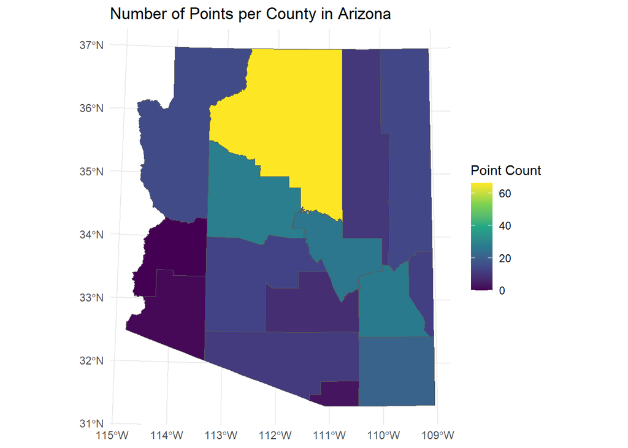

```r
county_counts <- az_county_intersections %>%
  group_by(NAME) %>%
  summarise(count = n())

az_counties_with_counts <- az_counties_sf %>%
  st_join(county_counts, by = "NAME") %>%
  mutate(count = replace_na(count, 0))


ggplot(az_counties_with_counts) +
  geom_sf(aes(fill = count)) +
  scale_fill_viridis_c(name = "Point Count") +
  theme_minimal() +
  labs(title = "Number of Points per County in Arizona")
```

```r
rm(county_counts, az_counties_with_counts, az_county_intersections)
```

```r
# Extract Coconino County
coconino_sf <- az_counties_sf %>%
  filter(NAME == "Coconino")

#filter large wildfire data to only Coconino County
az_fires_wf <- st_intersection(az_fires_wf[az_fires_wf$FireCause=="Human" | az_fires_wf$FireCause == "Natural",], coconino_sf)
```

For this portion of the study, we opted to start smaller by filtering the data down to only Coconino County. Coconino County has the most naturally occurring wildfires in the state by a good margin, and is home to part of the largest contiguous Ponderosa Pine forest in the United States.

#### Model

##### Additional Packages

```r
library(spatstat)
library(spmodel)
library(lubridate)
library(tidycensus)
library(ggmap)
```

##### Data Refinement & Additional Exploration

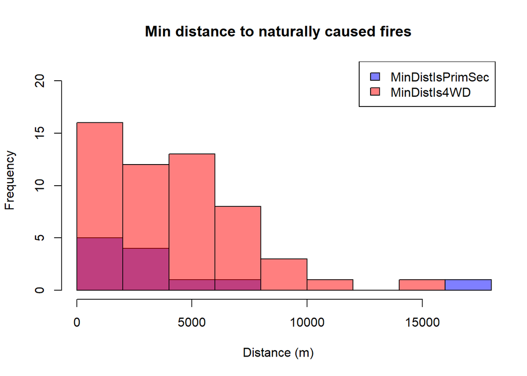

| WildFireType | Counts |
| --- | --- |
| Human Caused Fires | 6 |
| Naturally Caused Fires | 66 |
| Unknown Caused Fires | 0 |

##### Building a Background Poisson Process Realization

We will assign `az_fires_wf_spglm` as a placeholder `sf` object for whichever data we are interested in (for flexibility). For the report, we are only analyzing naturally caused “large” wildfires, hence it will be assigned using `az_fires_wf_nat` to generate `ppp` object and subsequent Poisson background realization points. Note that we are following a similar process as outlined in the *Random spatial index (point process) + Binary GLM* application in the *Non-Gaussian spatial data* lecture for the `gorillas` data.

```r
# set seed to 219 for report!
set.seed(219)

# set seed to 20 for predictions!
# set.seed(20)

# pick df of interest

az_fires_wf_spglm <- az_fires_wf_nat


az_fires_wf_spglm_ppp <- as.ppp(az_fires_wf_spglm)

background <- rpoispp((az_fires_wf_spglm_ppp$n) / area(as.owin(az_fires_wf_spglm_ppp)),
                      win = as.owin(coconino_sf))

df <- data.frame(x = background$x, y = background$y)

background_sf <- st_as_sf(df, coords = c("x", "y"), crs = "EPSG:32612")
```

```r
wf_sf_cc_plot <- st_as_sf(as.data.frame(az_fires_wf_spglm_ppp), coords = c("x", "y"), crs="EPSG:32612")

wf_sf_cc_plot <- st_transform(wf_sf_cc_plot, crs = 4326)

bkg_sf_cc_plot <- st_as_sf(as.data.frame(background), coords = c("x", "y"), crs="EPSG:32612")

bkg_sf_cc_plot <- st_transform(bkg_sf_cc_plot, crs = 4326)

coconino_plot <- coconino_sf %>% st_transform(4326)
az_cc_bbox <- st_bbox(coconino_plot)

az_cc_bbox <- c(
  left = az_cc_bbox["xmin"][[1]]-1,
  bottom = az_cc_bbox["ymin"][[1]]-1,
  right = az_cc_bbox["xmax"][[1]]+1,
  top = az_cc_bbox["ymax"][[1]]+1
)

coconino_map <- get_stadiamap(bbox = az_cc_bbox, zoom = 8)
```

```
## ℹ © Stadia Maps © Stamen Design © OpenMapTiles © OpenStreetMap contributors.
```

[output not shown]

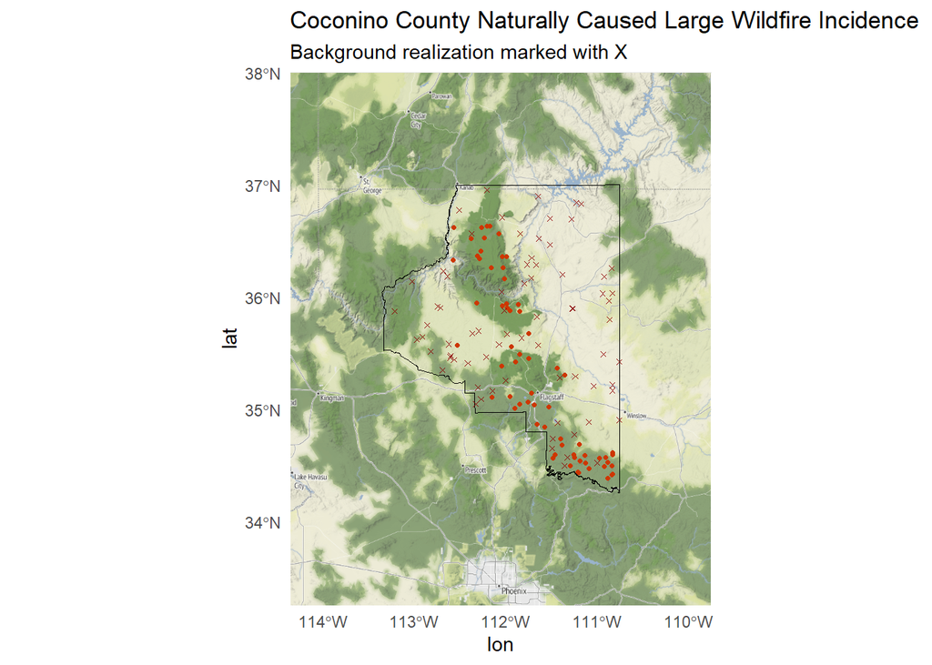

```r
# plot
ggmap(coconino_map) + labs(title = "Coconino County Naturally Caused Large Wildfire Incidence", subtitle = "Background realization marked with X") + theme_minimal() +
  geom_sf(data = coconino_plot, fill = NA, color = "black", size = 5, inherit.aes = FALSE) +
  geom_sf(data=wf_sf_cc_plot, shape = 21, size = 0.9,
          color = "orangered3", fill = "orangered3", inherit.aes = FALSE) +
  geom_sf(data=bkg_sf_cc_plot, shape = 4, size = 1.1, color = "red4", inherit.aes = FALSE)
```

We first generate a realization of a Poisson point process to represent where Naturally occurring wildfires could have happened in Cocinino County, a simple features object called `background_sf`. For each of the points in the realization opted to generate all of the covariate data, including the census data for population density as well as all of the natural data. The data was a collaborative effort and required some tedious construction of useable dataframes that are column binded to the `background_sf` object. Those details are omitted and the data is provided as an `RData` file that can be imported.

```r
df1 <- st_drop_geometry(az_fires_wf_spglm)
df2 <- st_drop_geometry(background_sf)


common_cols <- intersect(names(df1), names(df2))

df1 <- df1[, c(common_cols)]
df2 <- df2[, c(common_cols)]

df1$FireDiscoveryDateTime <- as.Date(df1$FireDiscoveryDateTime)
df2$FireDiscoveryDateTime <- as.Date(df2$FireDiscoveryDateTime)


Covariates <- rbind(df1, df2)

rm(df1,df2,df)

#### row bind to build a data_sf sf object for use in our model

all_points <- superimpose(unmark(az_fires_wf_spglm_ppp), background)

Wildfires <- c(rep(1, az_fires_wf_spglm_ppp$n), rep(0, background$n))

data <- cbind(Wildfires, Covariates)

data_sf <- st_as_sf(cbind(data, as.data.frame(all_points)[, c('x', 'y')]),
coords = c('x', 'y'))
```

A function to create categorical bins for season to use as predictors in wildfire incidence models.

```r
get_season <- function(date) {
  month <- as.integer(format(date, "%m"))
  season <- case_when(
    month %in% c(12, 1, 2) ~ 1,
    month %in% c(3, 4, 5) ~ 2,
    month %in% c(6, 7, 8) ~ 3,
    month %in% c(9, 10, 11) ~ 4
  )
  return(season)
}
```

We wanted to take as objective of an approach to building the model as possible. The below chunk produces the AIC for different variants of model fits. This approach is something like a “poor man’s” version of the `stepAIC` function from the `MASS` package that can give a best-AIC model and do variable selection in an automated way. This way is not automated, and below is only serving as an example of how some models were compared. The chunk cycles through each model in `formula_list` and does a fit for each of the different `cov_types`. It fits each model using `spglm` and `binary` response and computes AIC for the model, returning a list from which we can select the best AIC model.

```r
# Create a list of formula objects
formula_list <- list(
  as.formula("Wildfires ~ I(sqrt(distance_rd_min_prisec)) +
  I(sqrt(distance_rd_4wd)) + I(sqrt(distance_rd_min_isprisec)) +
  I(log(mean_slope)) + mean_forest + mean_grass + I(log(pop.density)) +
  Precipitation_Buffered + Temp_Min_Buffered + Temp_Max_Buffered +
  I(month(FireDiscoveryDateTime))"),
  as.formula("Wildfires ~  I(sqrt(distance_rd_min_isprisec)) +
  Precipitation_Buffered + Temp_Min_Buffered + I(get_season(FireDiscoveryDateTime)) +
  mean_grass * mean_forest"),
  as.formula("Wildfires ~  I(sqrt(distance_rd_min_isprisec)) + pop.density +
  Precipitation_Buffered + Temp_Min_Buffered + I(get_season(FireDiscoveryDateTime)) +
  mean_grass * mean_forest")

)

# Define spatial covariance types
# gaussian best for all so far
# OUT: cauchy and matern
cov_types <- c("wave",
               "gaussian",
               "spherical",
               "circular")

# Initialize a list to store results
results <- list()

# Outer loop for formulas
for (i in seq_along(formula_list)) {
  # Inner loop for spatial covariance types
  for (j in seq_along(cov_types)) {
    # Fit the model using spglm
    model <- spglm(formula_list[[i]], data = data_sf, family = binomial, spcov_initial = spcov_initial(cov_types[j]))

    # Store AIC in results list
    results[[paste0("Model_", i, "_", cov_types[j])]] <- AIC(model)
  }
}

kable(data.frame(AIC = unlist(results)))
```

|  | AIC |
| --- | --- |
| Model_1_wave | 117.1134 |
| Model_1_gaussian | 365.1477 |
| Model_1_spherical | 365.2596 |
| Model_1_circular | 364.9773 |
| Model_2_wave | 341.4249 |
| Model_2_gaussian | 342.3983 |
| Model_2_spherical | 342.8299 |
| Model_2_circular | 342.6206 |
| Model_3_wave | 315.3779 |
| Model_3_gaussian | 316.2855 |
| Model_3_spherical | 316.5638 |
| Model_3_circular | 316.3917 |

This is only any example to show one noteworthy result in this process. Some models returned unusually low AICs. Upon investigating, these very-low AIC models were actually just models whose coefficients did not converge. These models are discarded, hence the model we ultimately used.

Using lots of methodical trial and error, we selected the model in the below chunk by lowest AIC.

```r
# best AIC model

spglm_formula <- Wildfires ~  I(sqrt(distance_rd_min_isprisec)) + pop.density +
  Precipitation_Buffered + Temp_Min_Buffered + I(get_season(FireDiscoveryDateTime)) +
  mean_grass * mean_forest

az_wf_spcov <- spcov_initial("wave")

az_wf_spglm <- spglm(spglm_formula, data = data_sf,
                     family = binomial, spcov_initial = az_wf_spcov)
#check spcov_initial

summary(az_wf_spglm)
```

```
##
## Call:
## spglm(formula = spglm_formula, family = binomial, data = data_sf,
##     spcov_initial = az_wf_spcov)
##
## Deviance Residuals:
##      Min       1Q   Median       3Q      Max
## -2.76802 -0.37778 -0.07396  0.40712  2.61473
##
## Coefficients (fixed):
##                                        Estimate Std. Error z value Pr(>|z|)
## (Intercept)                          -2.798e+00  2.220e+00  -1.260   0.2076
## I(sqrt(distance_rd_min_isprisec))    -1.422e+00  8.157e-01  -1.743   0.0812 .
## pop.density                          -8.533e+04  1.522e+05  -0.561   0.5750
## Precipitation_Buffered                1.534e+00  9.588e-01   1.600   0.1096
## Temp_Min_Buffered                    -5.866e-01  2.646e-01  -2.217   0.0266 *
## I(get_season(FireDiscoveryDateTime))  5.327e-01  3.701e-01   1.439   0.1501
## mean_grass                            1.107e+00  1.678e+00   0.660   0.5095
## mean_forest                           1.444e+00  1.217e+00   1.186   0.2355
## mean_grass:mean_forest                1.560e+01  9.228e+00   1.690   0.0909 .
## ---
## Signif. codes:  0 '***' 0.001 '**' 0.01 '*' 0.05 '.' 0.1 ' ' 1
##
## Pseudo R-squared: 0.3718
##
## Coefficients (wave spatial covariance):
##        de        ie     range
## 2.860e+00 3.690e-02 3.772e+04
##
## Coefficients (Dispersion for binomial family):
## dispersion
##          1
```

```r
#model diagnostics

model_cv <- loocv(az_wf_spglm, type = "response")

kable(model_cv, caption = "Leave-One-Out Cross Validation")
```

Leave-One-Out Cross Validation

| bias | MSPE | RMSPE |
| --- | --- | --- |
| -5.67e-05 | 0.0821632 | 0.2866413 |

```r
kable(AIC(az_wf_spglm), caption = "Model AIC")
```

Model AIC

| x |
| --- |
| 315.3779 |

```r
# Create a grid of points
grid <- st_make_grid(coconino_sf, n = c(20, 20), what = "centers")

# Convert the grid to an sf object
grid_sf <- st_sf(geometry = grid)

# Filter points to keep only those inside Coconino County
coconino_grid <- grid_sf[coconino_sf, ]

# If you need exactly 200 points, you can sample from the resulting grid
coconino_grid_n <- coconino_grid %>%
  slice_sample(n = 400)

# Plot to verify
plot(st_geometry(coconino_sf))
plot(st_geometry(coconino_grid_n), add = TRUE, col = "red", pch = 20)

prediction_grid <- cbind(st_drop_geometry(coconino_grid_n), st_coordinates(coconino_grid_n))

prediction_grid$FireDiscoveryDateTime <- ymd_hm("2023-12-31 12:00")
```

[output not shown]

```r
az_prediction_grid <- read_csv(here('data/az_prediction_grid_utm_latlon.csv'))

# az_prediction_grid <- az_prediction_grid %>% select(c(-1))

az_prediction_grid_sf <- st_as_sf(az_prediction_grid, coords = c("X", "Y"), crs = "EPSG:32612")

az_prediction_grid_sf <- st_transform(az_prediction_grid_sf, crs = 4326)

# Extract coordinates
coords_4326 <- st_coordinates(az_prediction_grid_sf)

# Create a dataframe with original coordinates
df <- data.frame(
  lon = coords_4326[,1],
  lat = coords_4326[,2]
)

az_prediction_grid <- cbind(az_prediction_grid, df)
```

```r
az_prediction_grid_nat_covs <- read_csv(here('data/az_locations_all.csv'))

az_prediction_grid_nat_covs <- az_prediction_grid_nat_covs %>% select(,-c(1:5))

az_prediction_grid_sf <- cbind(az_prediction_grid_sf, az_prediction_grid_nat_covs)

az_prediction_grid_sf <- st_join(az_prediction_grid_sf, population_data, left = TRUE)



az_prediction_grid_sf$distance_rd_primary <-
  st_distance(az_prediction_grid_sf, az_rd_primary) %>% apply(1, min)

az_prediction_grid_sf$distance_rd_secondary <-
  st_distance(az_prediction_grid_sf, az_rd_secondary) %>% apply(1, min)

az_prediction_grid_sf$distance_rd_4wd <-
  st_distance(az_prediction_grid_sf, az_rd_4wd) %>% apply(1, min)


az_prediction_grid_sf <- az_prediction_grid_sf %>%
  mutate(distance_rd_min_prisec = pmin(distance_rd_primary,
                                    distance_rd_secondary))

az_prediction_grid_sf <- az_prediction_grid_sf %>%
  mutate(distance_rd_min_all = pmin(distance_rd_primary,
                                    distance_rd_secondary,
                                    distance_rd_4wd))

az_prediction_grid_sf$distance_rd_min_isprisec <- as.integer(az_prediction_grid_sf$distance_rd_min_all ==                                                     az_prediction_grid_sf$distance_rd_min_prisec)
```

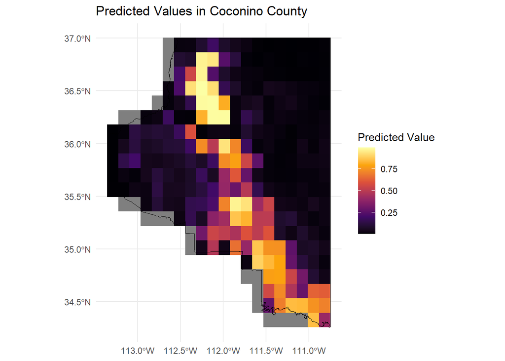

```r
load(here('data/az_prediction_grid_sf.RData'))

az_wf_predict_spglm <- predict(az_wf_spglm, type = "response", se.fit = T, newdata = az_prediction_grid_sf)

az_prediction_grid_sf$predict_bin_spglm <- az_wf_predict_spglm$fit

predict_plot <- st_transform(az_prediction_grid_sf, crs = 4326)


#generate pixel grid

plot_coconino_sf <- st_transform(coconino_sf, crs = 4326)

# Create a grid of squares
grid <- st_make_grid(plot_coconino_sf, n = c(20, 20), what = "polygons")

# Convert the grid to an sf object
grid_sf <- st_sf(geometry = grid)

# Filter squares to keep only those intersecting with Coconino County
coconino_grid <- grid_sf[plot_coconino_sf, ]

# Spatial join to transfer predicted values from points to grid squares
coconino_grid_with_values <- st_join(coconino_grid, predict_plot)

#plot

ggplot() +
  geom_sf(data = coconino_grid_with_values, aes(fill = predict_bin_spglm), color = NA) +
  geom_sf(data = coconino_sf, fill = NA, color = "black", size = 0.5) +
  scale_fill_viridis_c(option = "B") +
  theme_minimal() +
  labs(title = "Predicted Values in Coconino County",
       fill = "Predicted Value")
```